# Biostat 200C Homework 1

Due Apr 12 @ 11:59PM

Author

Ziheng Zhang_606300061

Published

April 12, 2024

To submit homework, please submit Rmd and html files to bruinlearn by the deadline.

## 1 Q1. Reivew of linear models

### 1.1 The swiss data — use Fertility as the response to practice

- An initial data analysis that explores the numerical and graphical characteristics of the data.

```r
library(tidyverse)
library(gtsummary)
library(GGally)
swiss1 <- as.tibble(swiss)
summary(swiss1)
```

```
   Fertility      Agriculture     Examination      Education
 Min.   :35.00   Min.   : 1.20   Min.   : 3.00   Min.   : 1.00
 1st Qu.:64.70   1st Qu.:35.90   1st Qu.:12.00   1st Qu.: 6.00
 Median :70.40   Median :54.10   Median :16.00   Median : 8.00
 Mean   :70.14   Mean   :50.66   Mean   :16.49   Mean   :10.98
 3rd Qu.:78.45   3rd Qu.:67.65   3rd Qu.:22.00   3rd Qu.:12.00
 Max.   :92.50   Max.   :89.70   Max.   :37.00   Max.   :53.00
    Catholic       Infant.Mortality
 Min.   :  2.150   Min.   :10.80
 1st Qu.:  5.195   1st Qu.:18.15
 Median : 15.140   Median :20.00
 Mean   : 41.144   Mean   :19.94
 3rd Qu.: 93.125   3rd Qu.:21.70
 Max.   :100.000   Max.   :26.60
```

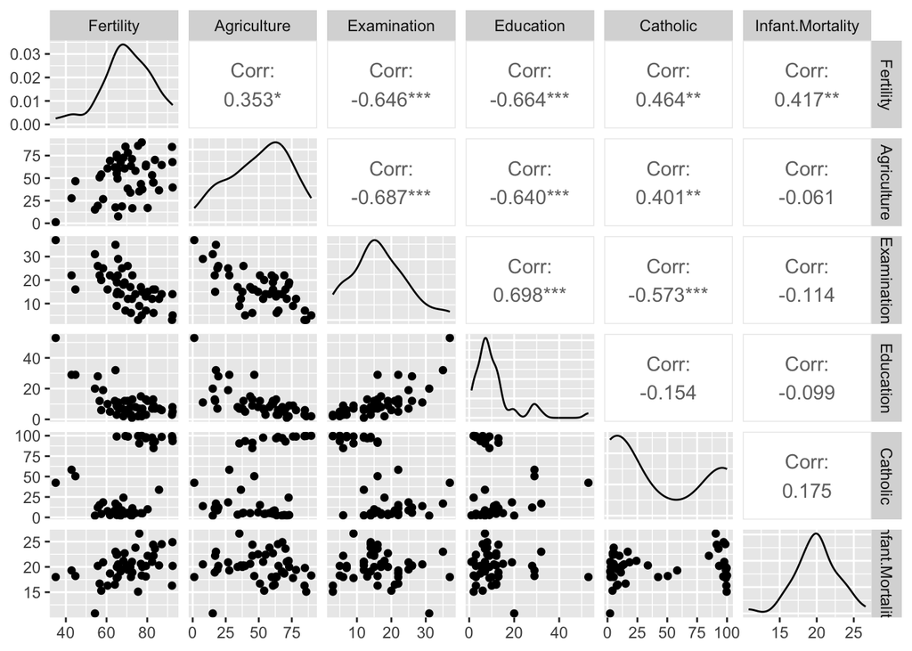

```r
ggpairs(swiss1)
```

**Answer:** The distributions of `Fertility` and `Agriculture` are left-skewed. The distributions of `Examination` and `Education` are right-skewed. The distribution of `Infant.Mortality` is roughly normal. Also the distributions of `Catholic` is bimodal. `Examination` is negatively correlated with `Fertility`, `Agriculture`, and `Catholic`. `Education` is negatively correlated with `Fertility` and `Agriculture`. `Examination` is positively correlated with `Education`.

- Variable selection to choose the best model.

```r
swiss_model1 <- lm(Fertility ~ ., data = swiss1)
summary(swiss_model1)
```

```
Call:
lm(formula = Fertility ~ ., data = swiss1)

Residuals:
     Min       1Q   Median       3Q      Max
-15.2743  -5.2617   0.5032   4.1198  15.3213

Coefficients:
                 Estimate Std. Error t value Pr(>|t|)
(Intercept)      66.91518   10.70604   6.250 1.91e-07 ***
Agriculture      -0.17211    0.07030  -2.448  0.01873 *
Examination      -0.25801    0.25388  -1.016  0.31546
Education        -0.87094    0.18303  -4.758 2.43e-05 ***
Catholic          0.10412    0.03526   2.953  0.00519 **
Infant.Mortality  1.07705    0.38172   2.822  0.00734 **
---
Signif. codes:  0 '***' 0.001 '**' 0.01 '*' 0.05 '.' 0.1 ' ' 1

Residual standard error: 7.165 on 41 degrees of freedom
Multiple R-squared:  0.7067,    Adjusted R-squared:  0.671
F-statistic: 19.76 on 5 and 41 DF,  p-value: 5.594e-10
```

```r
small_swiss <- step(swiss_model1, trace = TRUE)
```

```
Start:  AIC=190.69
Fertility ~ Agriculture + Examination + Education + Catholic +
    Infant.Mortality

                   Df Sum of Sq    RSS    AIC
- Examination       1     53.03 2158.1 189.86
<none>                          2105.0 190.69
- Agriculture       1    307.72 2412.8 195.10
- Infant.Mortality  1    408.75 2513.8 197.03
- Catholic          1    447.71 2552.8 197.75
- Education         1   1162.56 3267.6 209.36

Step:  AIC=189.86
Fertility ~ Agriculture + Education + Catholic + Infant.Mortality

                   Df Sum of Sq    RSS    AIC
<none>                          2158.1 189.86
- Agriculture       1    264.18 2422.2 193.29
- Infant.Mortality  1    409.81 2567.9 196.03
- Catholic          1    956.57 3114.6 205.10
- Education         1   2249.97 4408.0 221.43
```

```r
summary(small_swiss)
```

```
Call:
lm(formula = Fertility ~ Agriculture + Education + Catholic +
    Infant.Mortality, data = swiss1)

Residuals:
     Min       1Q   Median       3Q      Max
-14.6765  -6.0522   0.7514   3.1664  16.1422

Coefficients:
                 Estimate Std. Error t value Pr(>|t|)
(Intercept)      62.10131    9.60489   6.466 8.49e-08 ***
Agriculture      -0.15462    0.06819  -2.267  0.02857 *
Education        -0.98026    0.14814  -6.617 5.14e-08 ***
Catholic          0.12467    0.02889   4.315 9.50e-05 ***
Infant.Mortality  1.07844    0.38187   2.824  0.00722 **
---
Signif. codes:  0 '***' 0.001 '**' 0.01 '*' 0.05 '.' 0.1 ' ' 1

Residual standard error: 7.168 on 42 degrees of freedom
Multiple R-squared:  0.6993,    Adjusted R-squared:  0.6707
F-statistic: 24.42 on 4 and 42 DF,  p-value: 1.717e-10
```

**Answers:** The best model deletes `Examination` from the model. The best model is `Fertility ~ Agriculture + Education + Catholic + Infant.Mortality` and the adjusted R-squared is 0.6707.

- An exploration of transformations to improve the fit of the model.

**Answer:** From the graphical characteristics of the data, we should go down the ladders of `Education` to see if the model fit improves. We can try to fit the model with the log-transformed `Education` variables. Also, it seems we need to add quadratic terms for `Catholic` to the model.

```r
swiss1 <- swiss1 |>
  mutate(log_Education = log(Education),
         Catholic2 = Catholic^2)
swiss_model2 <- lm(Fertility ~ Agriculture + log_Education +
                     Catholic + Catholic2 + Infant.Mortality, data = swiss1)
summary(swiss_model2)
```

```
Call:
lm(formula = Fertility ~ Agriculture + log_Education + Catholic +
    Catholic2 + Infant.Mortality, data = swiss1)

Residuals:
     Min       1Q   Median       3Q      Max
-15.2614  -5.5143   0.1581   3.6523  23.6181

Coefficients:
                  Estimate Std. Error t value Pr(>|t|)
(Intercept)      61.734463  12.017969   5.137 7.21e-06 ***
Agriculture      -0.148838   0.082351  -1.807 0.078048 .
log_Education    -6.500539   2.150230  -3.023 0.004300 **
Catholic         -0.603475   0.227461  -2.653 0.011295 *
Catholic2         0.007122   0.002265   3.144 0.003100 **
Infant.Mortality  1.516620   0.425601   3.563 0.000946 ***
---
Signif. codes:  0 '***' 0.001 '**' 0.01 '*' 0.05 '.' 0.1 ' ' 1

Residual standard error: 8.112 on 41 degrees of freedom
Multiple R-squared:  0.6241,    Adjusted R-squared:  0.5783
F-statistic: 13.62 on 5 and 41 DF,  p-value: 7.62e-08
```

It seems that the model fit does not improve after log-transforming the `Education` variables. But the quadratic term for `Catholic` is significant. So we should keep the original variables and add the quadratic term for `Catholic` in the model.

```r
swiss_model3 <- lm(Fertility ~ Agriculture + Education +
                     Catholic + Catholic2 + Infant.Mortality, data = swiss1)
summary(swiss_model3)
```

```
Call:
lm(formula = Fertility ~ Agriculture + Education + Catholic +
    Catholic2 + Infant.Mortality, data = swiss1)

Residuals:
     Min       1Q   Median       3Q      Max
-13.6085  -4.5346  -0.0429   3.5102  16.0260

Coefficients:
                  Estimate Std. Error t value Pr(>|t|)
(Intercept)      62.540022   9.399288   6.654 5.09e-08 ***
Agriculture      -0.178813   0.068206  -2.622  0.01222 *
Education        -0.844850   0.165357  -5.109 7.89e-06 ***
Catholic         -0.242326   0.217699  -1.113  0.27214
Catholic2         0.003660   0.002153   1.700  0.09667 .
Infant.Mortality  1.177408   0.378059   3.114  0.00336 **
---
Signif. codes:  0 '***' 0.001 '**' 0.01 '*' 0.05 '.' 0.1 ' ' 1

Residual standard error: 7.012 on 41 degrees of freedom
Multiple R-squared:  0.7191,    Adjusted R-squared:  0.6849
F-statistic:    21 on 5 and 41 DF,  p-value: 2.362e-10
```

**Answers:** The best model is `Fertility ~ Agriculture + Education + Catholic + Catholic2 + Infant.Mortality`. And the adjusted R-squared is 0.6849.

- Diagnostics to check the assumptions of your model.

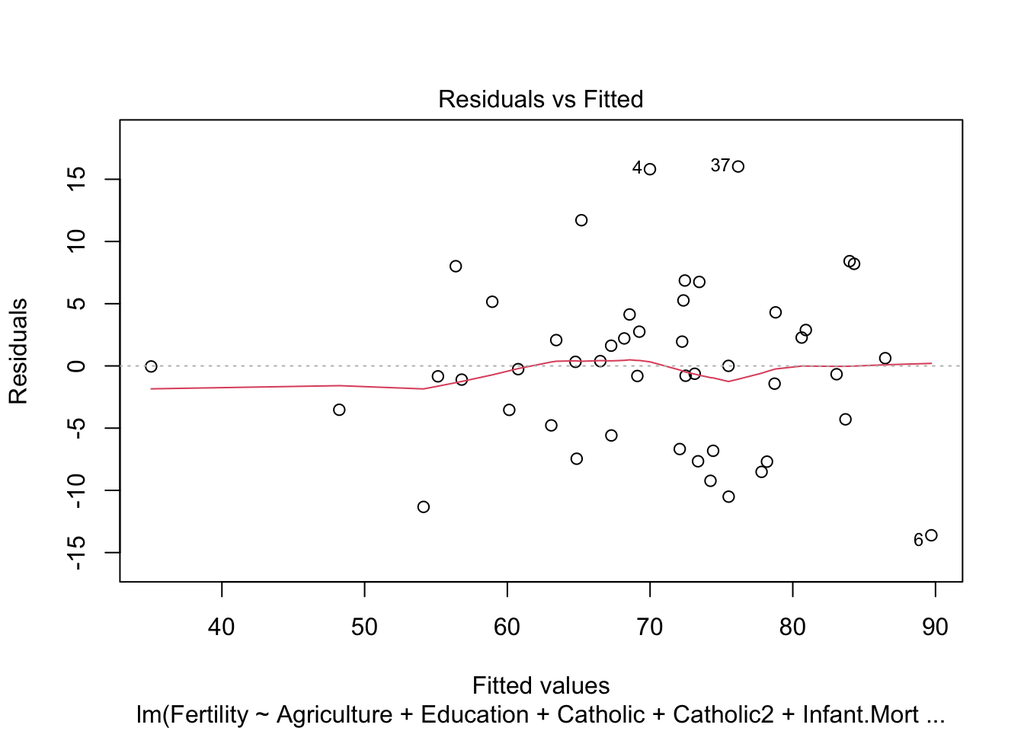

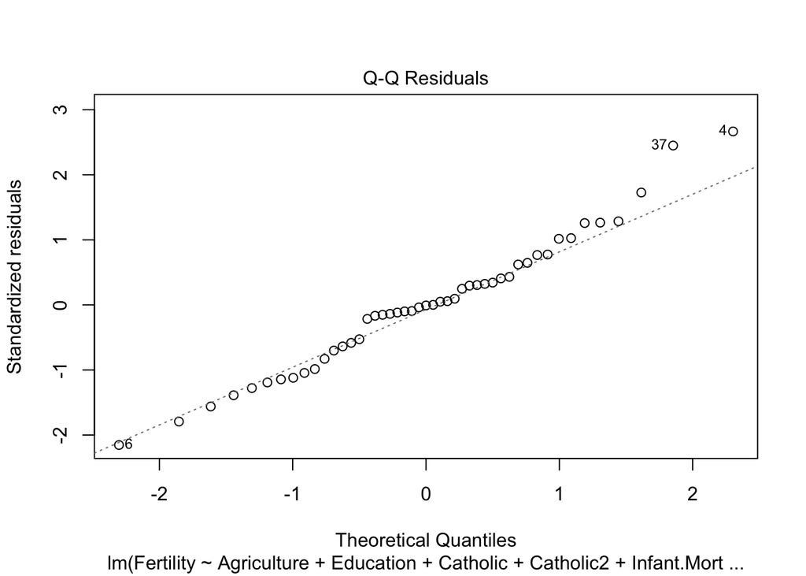

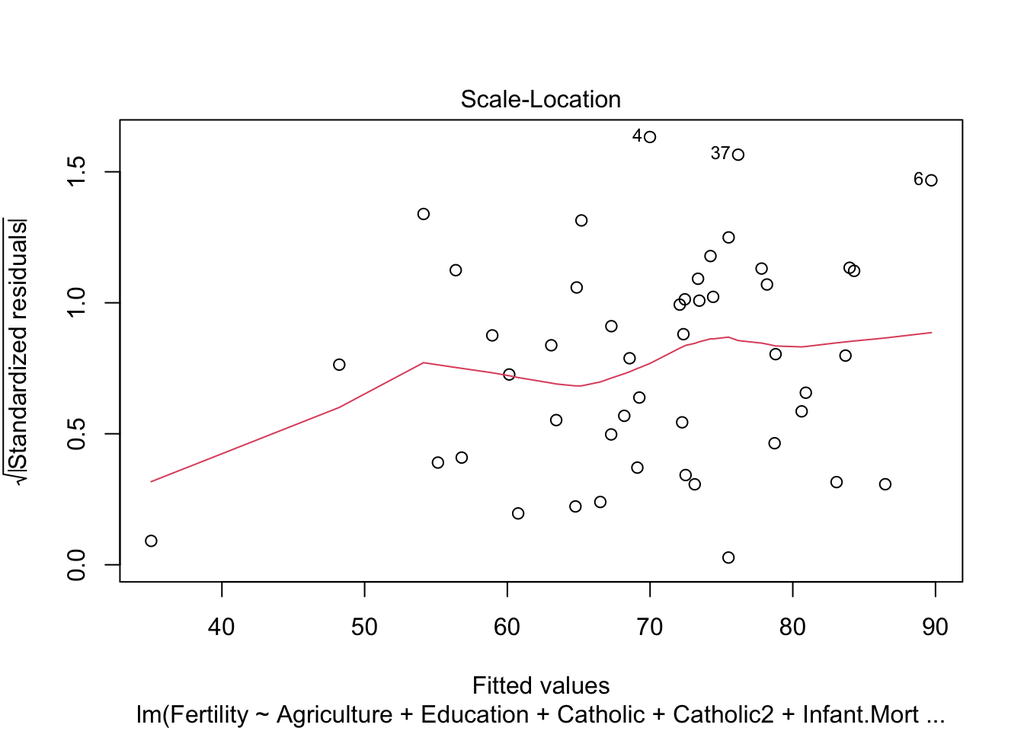

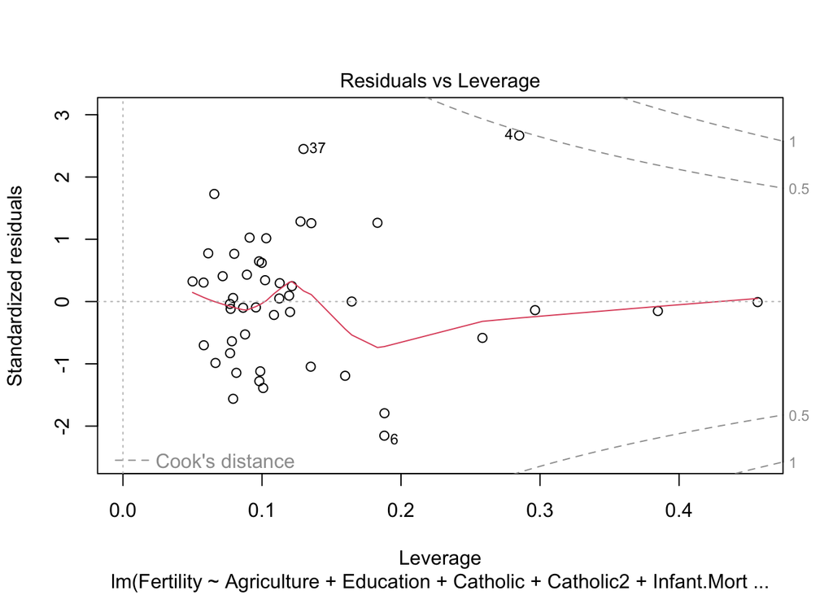

```r
plot(swiss_model3)
```

**Answers:** From the diagnostic plots, we can see that the assumptions are approximately met. The `Residuals vs Fitted` plot shows the residuals are randomly scattered around the zero line so the linearity and constant variance assumptions are met. The `Normal Q-Q` plot shows all points roughly follow a straight line so the normality assumption is met. From the `Scale-Location` plot, there is no special pattern so the constant variance assumption is met. The `Residuals vs Leverage` plot shows that there are 3 observations with high residuals and some observations with high leverage. There is one observation, 4, with relatively high Cook’s distance.

- Some predictions of future observations for interesting values of the predictors.

```r
new_data <- data.frame(Agriculture = c(mean(swiss1$Agriculture),
                                       median(swiss1$Agriculture)),
                       Education = c(mean(swiss1$Education),
                                      median(swiss1$Education)),
                       Catholic = c(mean(swiss1$Catholic),
                                     median(swiss1$Catholic)),
                       Infant.Mortality = c(mean(swiss1$Infant.Mortality),
                                            median(swiss1$Infant.Mortality))) |>
  mutate(Catholic2 = Catholic^2)
predict(swiss_model3, newdata = new_data)
```

```
       1        2
63.91213 66.82576
```

**Answers:** We are interested in the predictions of `Fertility` for the mean and median values of `Agriculture`, `Education`, `Catholic`, `Catholic^2`, and `Infant.Mortality`. The predictions are 63.91 and 66.83 for the mean and median values of the predictors, respectively.

- An interpretation of the meaning of the model by writing a scientific abstract. (<150 words)
  - BACKGROUND: The `swiss` data set represents `Swiss Fertility and Socioeconomic Indicators (1888) Data`. It provides information on the standardized fertility measure and socio-economic indicators for each of 47 French-speaking provinces of Switzerland at about 1888.
  - OBJECTIVE: This study aims to investigate the relationship between fertility (`Fertility`) and socio-economic indicators (`Agriculture`, `Examination`, `Education`, `Catholic`, and `Infant.Mortality`) in French-speaking provinces of Switzerland.
  - METHODS: We fit a linear regression model with `Fertility` as the response and all other variables as predictors. We perform variable selection and use AIC to select the best model and explore transformations based on each variable’s characteristics to improve the fit of the model. We check the assumptions of the model and make predictions of future observations for interesting values of the predictors.
  - RESULTS: We add the quadratic term for `Catholic` in the model. The best model is `Fertility ~ Agriculture + Education + Catholic + Catholic^2 + Infant.Mortality` and the adjusted R-squared is 0.6849 and only `Examination` is deleted from the model. `Catholic`, `Education`, and `Agriculture` have negative partial effects on `Fertility`. `Catholic^2` and `Infant.Mortality` have positive partial effects on `Fertility`.
  - CONCLUSIONS: The study of `swiss` data set explores relationship between socio-economic factors and fertility. If the government wants to reduce fertility, it should focus on increasing `Education` and decreasing `Infant.Mortality`.

## 2 Q2. Concavity of logistic regression log-likelihood

### 2.1 Q2.1

Write down the log-likelihood function of logistic regression for binomial responses.

**Answer:** Given $n$ data points $(y_{i}, \mathbf{x}_{i})$, $i=1,\ldots,n$, the **log-likelihood** is
$$\begin{eqnarray*}
\ell(\boldsymbol{\beta}) &=& \sum_{i} \log \left[p_{i}^{y_{i}} (1 - p_{i})^{1 - y_{i}}\right] \\
&=& \sum_{i} \left[ y_{i} \log p_{i} + (1 - y_{i}) \log (1 - p_{i}) \right] \\
&=& \sum_{i} \left[ y_{i} \log \frac{e^{\eta_{i}}}{1 + e^{\eta_{i}}} + (1 - y_{i}) \log \frac{1}{1 + e^{\eta_{i}}} \right] \\
&=& \sum_{i} \left[ y_{i} \eta_{i} - \log (1 + e^{\eta_{i}}) \right] \\
&=& \sum_{i} \left[ y_{i} \mathbf{x}_{i}^{T} \boldsymbol{\beta} - \log (1 + e^{\mathbf{x}_{i}^{T} \boldsymbol{\beta}}) \right]
\end{eqnarray*}$$

### 2.2 Q2.2

Derive the gradient vector and Hessian matrix of the log-likelhood function with respect to the regression coefficients $\boldsymbol{\beta}$.

**Answer:** The gradient vector is as follows:

$$\begin{eqnarray*}
\ell(\boldsymbol{\beta}) &=& \sum_i \left[ y_i \mathbf{x}_i^T \boldsymbol{\beta} - \log (1 + e^{\mathbf{x}_i^T \boldsymbol{\beta}}) \right] \\
\nabla_{\beta}(\mathbf{x}_{i}^{T} \boldsymbol{\beta}) &=& \nabla_{\beta}(1 \beta_0 + \mathbf{x}_{i1} \beta_1 + \cdots + \mathbf{x}_{iq} \beta_q) &=& \begin{pmatrix} 1 \\ \mathbf{x}_{i1} \\ \vdots \\ \mathbf{x}_{iq} \end{pmatrix} &=& \mathbf{x}_{i} \\
\nabla_{\beta} \ell(\boldsymbol{\beta}) &=& \sum_{i} \left[y_{i}(\nabla_{\beta} \mathbf{x}_{i}^{T} \boldsymbol{\beta}) - \nabla_{\beta} (\log (1 + e^{\mathbf{x}_{i}^{T} \boldsymbol{\beta}})) \right] \\
&=& \sum_{i} \left[y_{i} \mathbf{x}_{i} - \frac{e^{\mathbf{x}_{i}^T \boldsymbol{\beta}} \nabla_{\beta} \mathbf{x}_{i}^{T} \boldsymbol{\beta}}{1 + e^{\mathbf{x}_{i}^{T} \boldsymbol{\beta}}} \right] \\
&=& \sum_{i} \left[y_{i} \mathbf{x}_{i} - \frac{e^{\mathbf{x}_{i}^T \boldsymbol{\beta}} \mathbf{x}_{i}}{1 + e^{\mathbf{x}_{i}^{T} \boldsymbol{\beta}}} \right]
\end{eqnarray*}$$

So the Hessian matrix is as follows:
$$\begin{eqnarray*}
H_{\beta} &=& \nabla^{2}_{\beta} \ell(\boldsymbol{\beta})\\
&=& \sum_{i} \left[-\nabla_{\beta}\frac{e^{\mathbf{x}_{i}^T \boldsymbol{\beta}} \mathbf{x}_{i}}{1 + e^{\mathbf{x}_{i}^{T} \boldsymbol{\beta}}}\right] \\
&=& \sum_{i} \left[-\nabla_{\beta}\frac{\mathbf{x}_{i}}{1 + e^{-\mathbf{x}_{i}^{T} \boldsymbol{\beta}}}\right]\\
&=& \sum_{i} \left[-\nabla_{\beta}(1 + e^{- \mathbf{x}_{i}^{T} \boldsymbol{\beta}})^{-1} \begin{pmatrix} 1 \\ \mathbf{x}_{i1} \\ \vdots \\ \mathbf{x}_{iq} \end{pmatrix}\right] \\
&=& \sum_{i} \left[-\frac{e^{-\mathbf{x}_{i}^{T} \boldsymbol{\beta}}}{(1 + e^{-\mathbf{x}_{i}^{T} \boldsymbol{\beta}})^{2}} \mathbf{x}_{i}\mathbf{x}_{i}^{T} \right]
\end{eqnarray*}$$

### 2.3 Q2.3

Show that the log-likelihood function of logistic regression is a concave function in regression coefficients $\boldsymbol{\beta}$. (Hint: show that the negative Hessian is a positive semidefinite matrix.)

**Answer:** The negative Hessian matrix is as follows:
$$\begin{eqnarray*}
-H_{\beta} = \sum_{i} \left[\frac{e^{-\mathbf{x}_{i}^T \boldsymbol{\beta}}}{(1 + e^{-\mathbf{x}_{i}^{T} \boldsymbol{\beta}})^{2}} \mathbf{x}_{i}\mathbf{x}_{i}^{T} \right]
\end{eqnarray*}$$

Let $\mathbf{v}$ be any vector such that $\mathbf{v} \in \mathbb{R}^{q}$ and $\mathbf{v} \ne \mathbf{0}$. So we can get
$$\mathbf{v}^{T} (\mathbf{-H_{\beta}}) \mathbf{v} = \mathbf{v}^{T} \left( \sum_{i=1}^n \frac{e^{-\mathbf{x}_{i}^T \boldsymbol{\beta}}}{(1 + e^{-\mathbf{x}_{i}^{T} \boldsymbol{\beta}})^{2}} \mathbf{x}_{i}\mathbf{x}_{i}^{T} \right) \mathbf{v} = \sum_{i=1}^n \frac{e^{-\mathbf{x}_{i}^T \boldsymbol{\beta}}}{(1 + e^{-\mathbf{x}_{i}^{T} \boldsymbol{\beta}})^{2}} (\mathbf{x}_{i}^{T} \mathbf{v})^2 \ge 0,$$
since $\frac{e^{-\mathbf{x}_{i}^T \boldsymbol{\beta}}}{(1 + e^{-\mathbf{x}_{i}^{T} \boldsymbol{\beta}})^{2}} \ge 0$ and $(\mathbf{x}_{i}^{T} \mathbf{v})^2 \ge 0$.

So the negative Hessian is a positive semidefinite matrix and then the log-likelihood function of logistic regression is a concave function.

## 3 Q3.

The National Institute of Diabetes and Digestive and Kidney Diseases conducted a study on 768 adult female Pima Indians living near Phoenix. The purpose of the study was to investigate factors related to diabetes. The data may be found in the the dataset `pima`.

```r
library(faraway)
library(tidyverse)
pima1 <- as.tibble(pima) |>
  print(width = Inf)
```

```
# A tibble: 768 × 9
   pregnant glucose diastolic triceps insulin   bmi diabetes   age  test
      <int>   <int>     <int>   <int>   <int> <dbl>    <dbl> <int> <int>
 1        6     148        72      35       0  33.6    0.627    50     1
 2        1      85        66      29       0  26.6    0.351    31     0
 3        8     183        64       0       0  23.3    0.672    32     1
 4        1      89        66      23      94  28.1    0.167    21     0
 5        0     137        40      35     168  43.1    2.29     33     1
 6        5     116        74       0       0  25.6    0.201    30     0
 7        3      78        50      32      88  31      0.248    26     1
 8       10     115         0       0       0  35.3    0.134    29     0
 9        2     197        70      45     543  30.5    0.158    53     1
10        8     125        96       0       0   0      0.232    54     1
# ℹ 758 more rows
```

### 3.1 Q3.1

Create a factor version of the test results and use this to produce an interleaved histogram to show how the distribution of insulin differs between those testing positive and negative. Do you notice anything unbelievable about the plot?

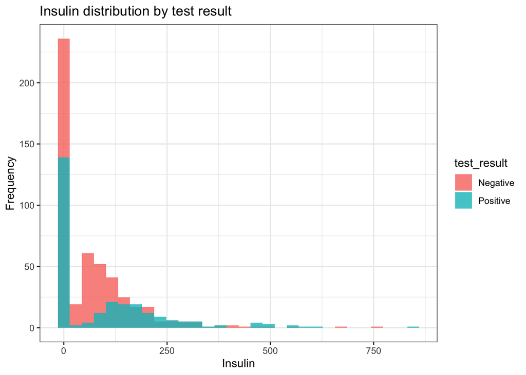

```r
pima1 <- pima1 |>
  mutate(test = as.factor(test)) |>
  mutate(test_result = ifelse(test == 1, "Positive", "Negative"))

  ggplot(pima1, aes(insulin, fill = test_result)) +
  geom_histogram(alpha = 0.8, position = "identity", bins = 30) +
  labs(title = "Insulin distribution by test result",
       x = "Insulin",
       y = "Frequency") +
    theme_bw()
```

**Answer:** From the plot, we can see that there are a lot of zero values in the insulin variable. It is impossible for a person to have zero insulin as insulin is a hormone in human’s body. So zero values in the insulin variable are missing values.

### 3.2 Q3.2

Replace the zero values of `insulin` with the missing value code `NA`. Recreate the interleaved histogram plot and comment on the distribution.

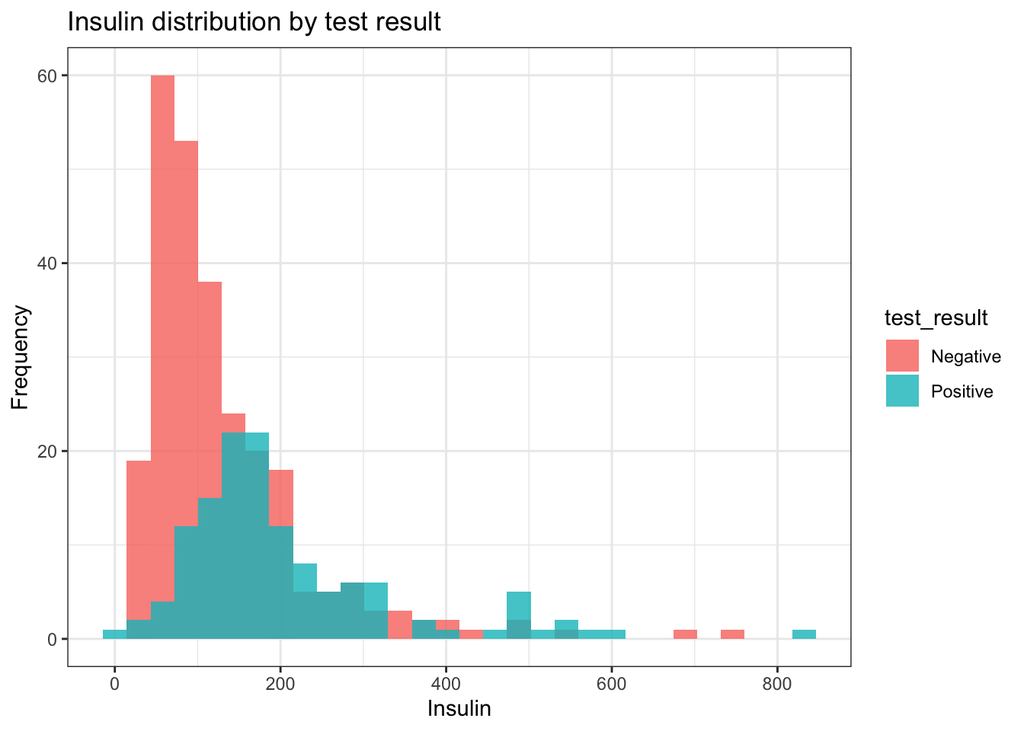

```r
pima1 <- pima1 |>
  mutate(insulin = ifelse(insulin == 0, NA, insulin))

ggplot(pima1, aes(insulin, fill = test_result)) +
  geom_histogram(alpha = 0.8, position = "identity", bins = 30) +
  labs(title = "Insulin distribution by test result",
       x = "Insulin",
       y = "Frequency") +
  theme_bw()
```

**Answer:** After replacing the zero values with missing value code `NA`, the plot shows that the distribution of insulin is right-skewed. The distribution of insulin is different between those testing positive and negative. There are more cases in low insulin level for those who tested negative than those who tested positive for diabetes.

### 3.3 Q3.3

Replace the incredible zeroes in other variables with the missing value code. Fit a model with the result of the diabetes test as the response and all the other variables as predictors. How many observations were used in the model fitting? Why is this less than the number of observations in the data frame.

```r
summary(pima1)
```

```
    pregnant         glucose        diastolic         triceps
 Min.   : 0.000   Min.   :  0.0   Min.   :  0.00   Min.   : 0.00
 1st Qu.: 1.000   1st Qu.: 99.0   1st Qu.: 62.00   1st Qu.: 0.00
 Median : 3.000   Median :117.0   Median : 72.00   Median :23.00
 Mean   : 3.845   Mean   :120.9   Mean   : 69.11   Mean   :20.54
 3rd Qu.: 6.000   3rd Qu.:140.2   3rd Qu.: 80.00   3rd Qu.:32.00
 Max.   :17.000   Max.   :199.0   Max.   :122.00   Max.   :99.00

    insulin            bmi           diabetes           age        test
 Min.   : 14.00   Min.   : 0.00   Min.   :0.0780   Min.   :21.00   0:500
 1st Qu.: 76.25   1st Qu.:27.30   1st Qu.:0.2437   1st Qu.:24.00   1:268
 Median :125.00   Median :32.00   Median :0.3725   Median :29.00
 Mean   :155.55   Mean   :31.99   Mean   :0.4719   Mean   :33.24
 3rd Qu.:190.00   3rd Qu.:36.60   3rd Qu.:0.6262   3rd Qu.:41.00
 Max.   :846.00   Max.   :67.10   Max.   :2.4200   Max.   :81.00
 NA's   :374
 test_result
 Length:768
 Class :character
 Mode  :character
```

**Answer:** It seems the incredible zeroes are in the variables `glucose`, `diastolic`, `triceps`, and `bmi`. We can replace the incredible zeroes with the missing value code `NA` for these variables.

```r
pima1 <- pima1 |>
  mutate(
    glucose = ifelse(glucose == 0, NA, glucose),
    diastolic = ifelse(diastolic == 0, NA, diastolic),
    triceps = ifelse(triceps == 0, NA, triceps),
    bmi = ifelse(bmi == 0, NA, bmi)
  )
```

```r
pima_model1 <- glm(test ~ pregnant + glucose + diastolic + triceps + insulin +
                     bmi + diabetes + age, data = pima1, family = binomial)
summary(pima_model1)
```

```
Call:
glm(formula = test ~ pregnant + glucose + diastolic + triceps +
    insulin + bmi + diabetes + age, family = binomial, data = pima1)

Coefficients:
              Estimate Std. Error z value Pr(>|z|)
(Intercept) -1.004e+01  1.218e+00  -8.246  < 2e-16 ***
pregnant     8.216e-02  5.543e-02   1.482  0.13825
glucose      3.827e-02  5.768e-03   6.635 3.24e-11 ***
diastolic   -1.420e-03  1.183e-02  -0.120  0.90446
triceps      1.122e-02  1.708e-02   0.657  0.51128
insulin     -8.253e-04  1.306e-03  -0.632  0.52757
bmi          7.054e-02  2.734e-02   2.580  0.00989 **
diabetes     1.141e+00  4.274e-01   2.669  0.00760 **
age          3.395e-02  1.838e-02   1.847  0.06474 .
---
Signif. codes:  0 '***' 0.001 '**' 0.01 '*' 0.05 '.' 0.1 ' ' 1

(Dispersion parameter for binomial family taken to be 1)

    Null deviance: 498.10  on 391  degrees of freedom
Residual deviance: 344.02  on 383  degrees of freedom
  (376 observations deleted due to missingness)
AIC: 362.02

Number of Fisher Scoring iterations: 5
```

**Answer:** The number of observations used in the model fitting is 392. This is less than the number of observations in the data frame because the incredible zeroes in the variables `glucose`, `diastolic`, `triceps`, `insulin` and `bmi` are replaced with the missing value code `NA`. And these 376 observations are deleted due to missingness.

### 3.4 Q3.4

Refit the model but now without the insulin and triceps predictors. How many observations were used in fitting this model? Devise a test to compare this model with that in the previous question.

```r
pima_model2 <- glm(test ~ pregnant + glucose + diastolic + bmi + diabetes + age,
                   data = pima1, family = binomial)
summary(pima_model2)
```

```
Call:
glm(formula = test ~ pregnant + glucose + diastolic + bmi + diabetes +
    age, family = binomial, data = pima1)

Coefficients:
             Estimate Std. Error z value Pr(>|z|)
(Intercept) -8.962146   0.820892 -10.918  < 2e-16 ***
pregnant     0.117863   0.033418   3.527  0.00042 ***
glucose      0.035194   0.003605   9.763  < 2e-16 ***
diastolic   -0.008916   0.008618  -1.035  0.30084
bmi          0.090926   0.015740   5.777 7.61e-09 ***
diabetes     0.960515   0.306415   3.135  0.00172 **
age          0.016944   0.009834   1.723  0.08489 .
---
Signif. codes:  0 '***' 0.001 '**' 0.01 '*' 0.05 '.' 0.1 ' ' 1

(Dispersion parameter for binomial family taken to be 1)

    Null deviance: 931.94  on 723  degrees of freedom
Residual deviance: 672.86  on 717  degrees of freedom
  (44 observations deleted due to missingness)
AIC: 686.86

Number of Fisher Scoring iterations: 5
```

**Answer:** There are 724 observations used in fitting this model and 44 observations are deleted due to missingness.

```r
pima_model1 <- glm(test ~ pregnant + glucose + diastolic + triceps + insulin +
                     bmi + diabetes + age, data = na.omit(pima1),
                   family = binomial)
pima_model2 <- glm(test ~ pregnant + glucose + diastolic + bmi + diabetes + age,
                   data = na.omit(pima1), family = binomial)
anova(pima_model1, pima_model2, test = "Chi")
```

```
Analysis of Deviance Table

Model 1: test ~ pregnant + glucose + diastolic + triceps + insulin + bmi +
    diabetes + age
Model 2: test ~ pregnant + glucose + diastolic + bmi + diabetes + age
  Resid. Df Resid. Dev Df Deviance Pr(>Chi)
1       383     344.02
2       385     344.88 -2 -0.85931   0.6507
```

**Answer:** The p-value is $0.6507 > 0.05$, so we fail to reject the null hypothesis. There is no significant evidence that the model without `insulin` and `triceps` predictors is significantly different from the model with them.

### 3.5 Q3.5

Use AIC to select a model. You will need to take account of the missing values. Which predictors are selected? How many cases are used in your selected model?

```r
biglm <- glm(test ~ pregnant + glucose + diastolic + triceps + insulin +
               bmi + diabetes + age, data = na.omit(pima1), family = binomial)
smalllm <- step(biglm, trace = TRUE)
```

```
Start:  AIC=362.02
test ~ pregnant + glucose + diastolic + triceps + insulin + bmi +
    diabetes + age

            Df Deviance    AIC
- diastolic  1   344.04 360.04
- insulin    1   344.42 360.42
- triceps    1   344.45 360.45
<none>           344.02 362.02
- pregnant   1   346.24 362.24
- age        1   347.55 363.55
- bmi        1   350.89 366.89
- diabetes   1   351.58 367.58
- glucose    1   396.95 412.95

Step:  AIC=360.04
test ~ pregnant + glucose + triceps + insulin + bmi + diabetes +
    age

           Df Deviance    AIC
- insulin   1   344.42 358.42
- triceps   1   344.46 358.46
<none>          344.04 360.04
- pregnant  1   346.24 360.24
- age       1   347.60 361.60
- bmi       1   351.28 365.28
- diabetes  1   351.67 365.67
- glucose   1   397.31 411.31

Step:  AIC=358.42
test ~ pregnant + glucose + triceps + bmi + diabetes + age

           Df Deviance    AIC
- triceps   1   344.89 356.89
<none>          344.42 358.42
- pregnant  1   346.74 358.74
- age       1   347.87 359.87
- bmi       1   351.32 363.32
- diabetes  1   351.90 363.90
- glucose   1   411.11 423.11

Step:  AIC=356.89
test ~ pregnant + glucose + bmi + diabetes + age

           Df Deviance    AIC
<none>          344.89 356.89
- pregnant  1   347.23 357.23
- age       1   348.72 358.72
- diabetes  1   352.72 362.72
- bmi       1   360.44 370.44
- glucose   1   411.85 421.85
```

```r
summary(smalllm)
```

```
Call:
glm(formula = test ~ pregnant + glucose + bmi + diabetes + age,
    family = binomial, data = na.omit(pima1))

Coefficients:
             Estimate Std. Error z value Pr(>|z|)
(Intercept) -9.992080   1.086866  -9.193  < 2e-16 ***
pregnant     0.083953   0.055031   1.526 0.127117
glucose      0.036458   0.004978   7.324 2.41e-13 ***
bmi          0.078139   0.020605   3.792 0.000149 ***
diabetes     1.150913   0.424242   2.713 0.006670 **
age          0.034360   0.017810   1.929 0.053692 .
---
Signif. codes:  0 '***' 0.001 '**' 0.01 '*' 0.05 '.' 0.1 ' ' 1

(Dispersion parameter for binomial family taken to be 1)

    Null deviance: 498.10  on 391  degrees of freedom
Residual deviance: 344.89  on 386  degrees of freedom
AIC: 356.89

Number of Fisher Scoring iterations: 5
```

**Answer:** The predictors selected are `pregnant`, `age`, `diabetes`, `bmi`, and `glucose`. There are 392 cases used in the selected model.

### 3.6 Q3.6

Create a variable that indicates whether the case contains a missing value. Use this variable as a predictor of the test result. Is missingness associated with the test result? Refit the selected model, but now using as much of the data as reasonable. Explain why it is appropriate to do this.

```r
pima2 <- pima |>
  mutate(
    glucose2  = ifelse(glucose == 0, NA, glucose),
    diastolic2 = ifelse(diastolic == 0, NA, diastolic),
    triceps2 = ifelse(triceps == 0, NA, triceps),
    insulin2 = ifelse(insulin == 0, NA, insulin),
    bmi2 = ifelse(bmi == 0, NA, bmi),
    diabetes2 = ifelse(diabetes == 0, NA, diabetes),
    age2 = ifelse(age == 0, NA, age))

pima2 <- pima2 |>
  mutate(missingNA = ifelse(rowSums(is.na(pima2[, 10:16])) > 0, 1, 0))

pima_missing <- glm(test ~ missingNA, family = binomial(), data = pima2)

library(gtsummary)
pima_missing |>
  tbl_regression() |>
  bold_labels() |>
  bold_p(t = 0.05)
```

| **Characteristic** | **log(OR)**<sup>1</sup> | **95% CI**<sup>1</sup> | **p-value** |
| --- | --- | --- | --- |
| missingNA | 0.16 | -0.14, 0.45 | 0.3 |

<sup>1</sup> OR = Odds Ratio, CI = Confidence Interval

From above regression, we find missingness is not associate with outcome. This means that the distribution of outcome when removing data with missing is still a representative of the original distribution. This justifies the use of “complete case” analysis.

**Answer:** It is appropriate to refit the selected model using as much of the data as reasonable because missingness is not associated with the test result. So we can assume that the missing data is missing completely at random and then if we only drop the missing data, the distribution of the outcome is still representative of the original distribution. Here we use 752 observations in the selected model.

```r
pima_model3 <- glm(test ~ pregnant + glucose + bmi + diabetes + age,
                   data = pima1, family = binomial)
summary(pima_model3)
```

```
Call:
glm(formula = test ~ pregnant + glucose + bmi + diabetes + age,
    family = binomial, data = pima1)

Coefficients:
             Estimate Std. Error z value Pr(>|z|)
(Intercept) -9.322789   0.737279 -12.645  < 2e-16 ***
pregnant     0.115058   0.032341   3.558 0.000374 ***
glucose      0.035941   0.003555  10.110  < 2e-16 ***
bmi          0.087529   0.014722   5.945 2.76e-09 ***
diabetes     0.920583   0.300832   3.060 0.002212 **
age          0.011366   0.009315   1.220 0.222405
---
Signif. codes:  0 '***' 0.001 '**' 0.01 '*' 0.05 '.' 0.1 ' ' 1

(Dispersion parameter for binomial family taken to be 1)

    Null deviance: 974.75  on 751  degrees of freedom
Residual deviance: 703.24  on 746  degrees of freedom
  (16 observations deleted due to missingness)
AIC: 715.24

Number of Fisher Scoring iterations: 5
```

### 3.7 Q3.7

Using the last fitted model of the previous question, what is the difference in the log-odds of testing positive for diabetes for a woman with a BMI at the first quartile compared with a woman at the third quartile, assuming that all other factors are held constant? Give a confidence interval for this difference.

```r
library(kableExtra)
bmi_iqr <- quantile(pima1$bmi, 0.75, na.rm = TRUE) -
  quantile(pima1$bmi, 0.25, na.rm = TRUE)
unname(bmi_iqr)
```

```
[1] 9.1
```

```r
logodds_diff <- bmi_iqr * coef(pima_model3)["bmi"]
unname(logodds_diff)
```

```
[1] 0.7965152
```

```r
confint(pima_model3, "bmi")[1] * bmi_iqr
```

```
    2.5 %
0.5387986
```

```r
confint(pima_model3, "bmi")[2] * bmi_iqr
```

```
  97.5 %
1.064765
```

**Answer:** The $IQR$ for `bmi` is $9.1$. So the difference in the log-odds of testing positive for diabetes for a women with a BMI at the first quantile compared with a women at the third quantile is $\hat{\beta}_{bmi} \times IQR = 0.08753 \times 9.1 = 0.797$. The $95\%$ confidence interval for coefficient of `bmi` is $(0.059, 0.117)$. So we multiply $9.1$ to get the $95\%$ confidence interval for log-odds difference, i.e. $(0.539, 1.065)$. This means that we are $95\%$ confident that the the difference in the log-odds is between $0.539$ and $1.065$.

### 3.8 Q3.8

Do women who test positive have higher diastolic blood pressures? Is the diastolic blood pressure significant in the regression model? Explain the distinction between the two questions and discuss why the answers are only apparently contradictory.

```r
wilcox.test(diastolic ~ test_result, data = pima1, alternative = "less")
```

```
    Wilcoxon rank sum test with continuity correction

data:  diastolic by test_result
W = 47566, p-value = 8.143e-07
alternative hypothesis: true location shift is less than 0
```

**Answer:** From the Wilcoxon test, we find that the p-value is $8.143*10^{-7} < 0.05$, so we conclude that women who test positive have higher diastolic blood pressures.

```r
summary(pima_model1)
```

```
Call:
glm(formula = test ~ pregnant + glucose + diastolic + triceps +
    insulin + bmi + diabetes + age, family = binomial, data = na.omit(pima1))

Coefficients:
              Estimate Std. Error z value Pr(>|z|)
(Intercept) -1.004e+01  1.218e+00  -8.246  < 2e-16 ***
pregnant     8.216e-02  5.543e-02   1.482  0.13825
glucose      3.827e-02  5.768e-03   6.635 3.24e-11 ***
diastolic   -1.420e-03  1.183e-02  -0.120  0.90446
triceps      1.122e-02  1.708e-02   0.657  0.51128
insulin     -8.253e-04  1.306e-03  -0.632  0.52757
bmi          7.054e-02  2.734e-02   2.580  0.00989 **
diabetes     1.141e+00  4.274e-01   2.669  0.00760 **
age          3.395e-02  1.838e-02   1.847  0.06474 .
---
Signif. codes:  0 '***' 0.001 '**' 0.01 '*' 0.05 '.' 0.1 ' ' 1

(Dispersion parameter for binomial family taken to be 1)

    Null deviance: 498.10  on 391  degrees of freedom
Residual deviance: 344.02  on 383  degrees of freedom
AIC: 362.02

Number of Fisher Scoring iterations: 5
```

**Answer:** The p-value for `diastolic` is 0.9 and it is not significant in the regression model. The distinction between the two questions is that the first question is about the marginal relationship between the diastolic blood pressure and the test result, while the second question is about the partial relationship between the diastolic blood pressure and the test result after controlling for other variables. The answers are only apparently contradictory.